# Imputation with constraints

## Introduction

In this work a method to correct imputed data subject to constraints is programmed in the so-called R language. It is based on the method presented in reference [1] in the section 10.11 Constrain Value Adjustment and try to extend it. Boyle-Dykstra Projection Algorithm is used.

## Imputation with constraints

The object of study of this work are data sets whose variables has to satisfy some restrictions tha can be give in form of ecuations. This data set initally could have missing values which are imputed with some imputation technique (median, mean,linear regression….)

For example let be the next set, in which we have already done the imputation or initialy there were not missing values. In this DataFrame we have four individuals and three variables for each one.

|  | x1 | x2 | x3 |
| --- | --- | --- | --- |
| ind1 | 0 | 0 | -3 |
| ind2 | 1 | 7 | 0 |
| ind3 | 0 | 1 | 1 |
| ind4 | 2 | 1 | 3 |

And this data point ($x=(x_1,x_2,x_3)$) has to satisfy the next restrictions:

$$\left \lbrace \begin{array}{c}
x_1+x_2+x_3 \leq 1 \\
x_1+2x_2+3x_3 \leq -6 \\
x_1 \leq 3
\end{array} \right.$$

Each of this ecuations can be seen as subset $C_i$ of the “space” to which each data point has to belong.

If a data point ($x$) doesn´t satisfy some ecuation ($C_i$) a better option can be consider other point “near” to the original but satisfaying them.

So the problem to solve can be watch as follow, for each data point ($x_0$) not satisfaying the restrictions $C = \cap_i C_i$ find the “nearest” point $x'$ that satisfy them (Best Approximation Problem):

$$|x'-x_0| = min \{ |x-x_0|: x \in C \}$$

Where at first the restrictions $C_i$ can be given by nonlinear equations, for example:

$$|x|\leq r^2$$
(type ball restriction)

For the example data frame: $x_1^2+x_2^2+x_3^2 \leq r^2$

To solve this problem we use the Boyle-Dykstra Projection Algorithm, that presented below.

### Boyle-Dykstra Projection Algorithm

The algorithm is given by the following expression [2]:

$$\left\{\begin{array}{l}
x_n=p_{C_{[n]}}(x_{n-1}+e_{n-r}),\\
e_n=x_{n-1}+e_{n-r}-x_n,\\
e_{-(r-1)}=\cdots=e_{-1}=e_0=0 \ ,\ x_0 = x.
\end{array}\right.$$
Where $[n]$ denote $``n\ mod\ r"$, $r$ is the number of subsets $C_i$ and $p_i$ is the projection operator onto $C_i$.

The algorithm project the initial value $x_0$ on the subsets alternately, but adding the vector $e_i$ (associated with the corresponding subset) before the projection. Thanks to this vectors $e_i$ the algorithm converge to the porjection of $x$ on $C = \cap_i^r C_i$.

For a better understanding of the algorithm and the efect of those $e_i$ lets visualize the next examples for some iterations. In each of this examples the subsets are painted in blue and the shaded region is the intersection of these (the “valid region”), the projection are the black lines and the vectors $e_i$ are represented by the red lines.

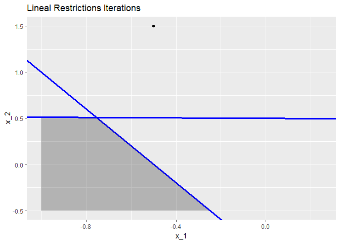

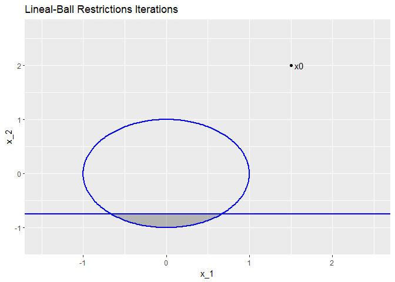

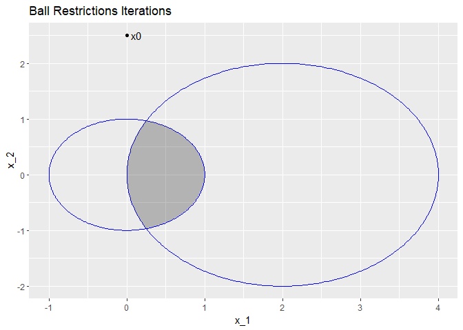

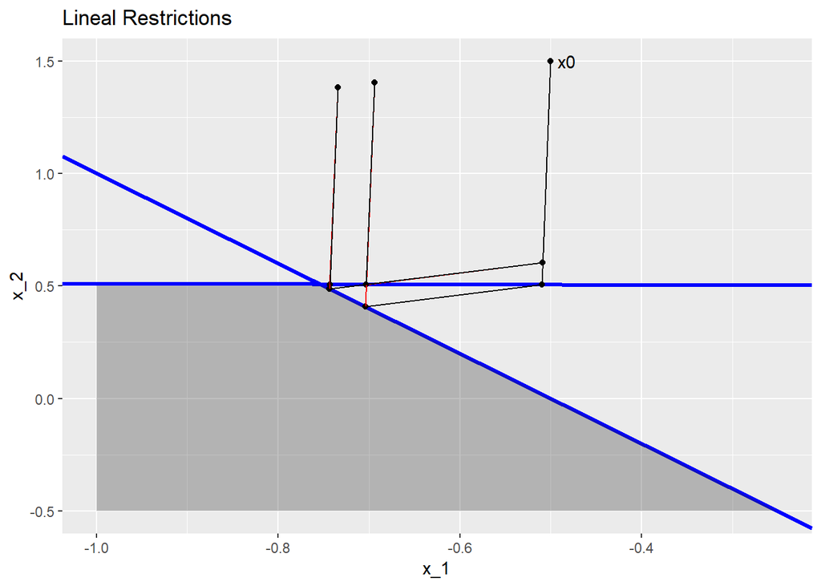

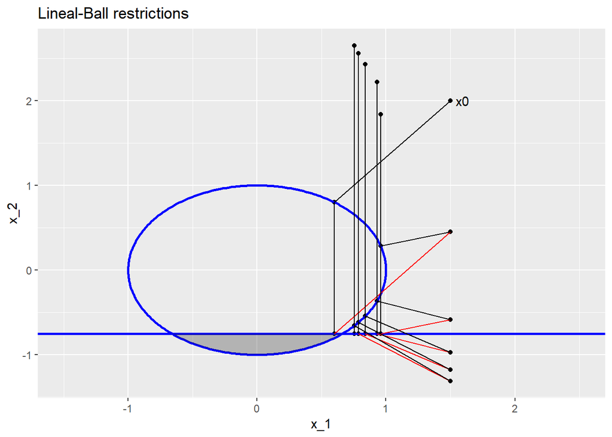

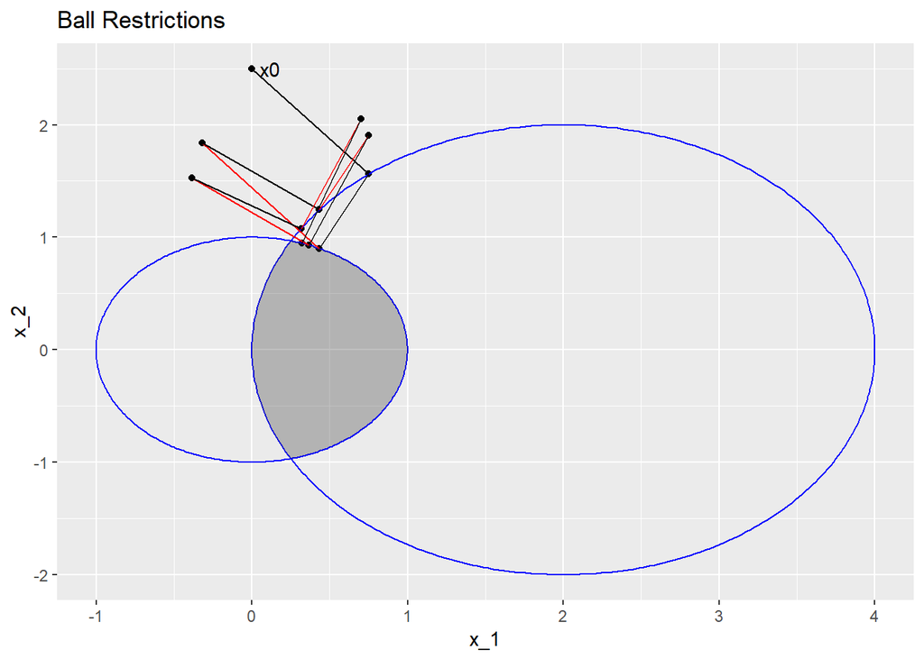

If there weren´t the vectors $e_i$ we would obtain a point inside $C$ which is the closest to the original only in the case in which the constraints define lineal equations. The Boyle-Dykstra algoritm is valid for any contraint defining convex sets.

## Example

In this section we present an example of how using the functions to adjust the data of a DataFrame to some constraints.

```r
# Data Frame
col1 = c(0,1,0,2)
col2 = c(0,7,1,1)
col3 = c(-3,0,1,3)
DF = data.frame(col1,col2,col3)
# We define the matrix and the independent terms
a1 = c(1,1,1)
a2 = c(1,2,3)
a3 = c(1,0,0)
A = matrix(c(a1, a2, a3), nrow = 3, ncol = length(a1), byrow = TRUE)
b = c(1,-6,3)
# Use the function
dykstra_DF(DF, typeConstraints = "lineal", A = A, b = b)
```

[output not shown]

## References

[1] E. Jonge y M. Loo. Statistical Data Cleaning with Applications in R. Wiley, 2018.

[2]F. Deutsch. Best Approximation in Inner Product Spaces. Springer, 2001.